# Raport ilustrare repartitii discrete si continue

### Ex 11

Se calculeaza probabilitatea ca o femeie sa aiba o anumita greutate, fiind generata o secventa de valori dupa o medie de 55 kg si o abatere de 5 kg.

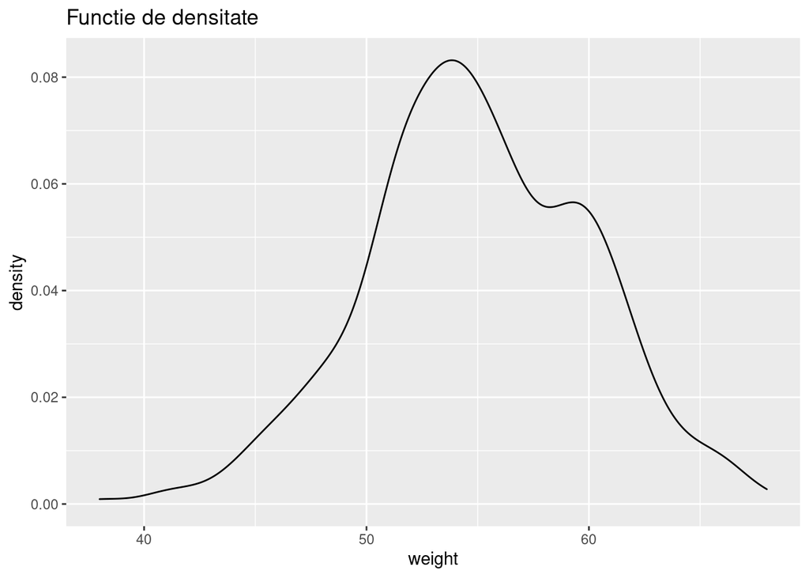

```r
            library(ggplot2)
            b = 60
            set.seed(5)

            df <- data.frame(
                sex=factor(rep(c("F", "M"), each=400)),
                weight=round(c(rnorm(400, mean=55, sd=5))
                ))

            f11 = function(x){
                return(dnorm(x=x, mean = 55, sd = 5))
            }

            F11 = function(xx){
                return(pnorm(q=xx, mean = 55, sd = 5))
            }

            P11 = function(a, b=NULL, param=NULL)
            {
                if(is.null(b))
                {
                    if(is.null(param))
                    {
                        return(F11(a))
                    }
                    else
                    {
                        return (1 - F11(a))
                    }
                }
                else
                {
                    return (F11(b) - F11(a))
                }
            }


                ggplot(df, aes(x=weight)) + geom_density() + ggtitle("Functie de densitate")
```

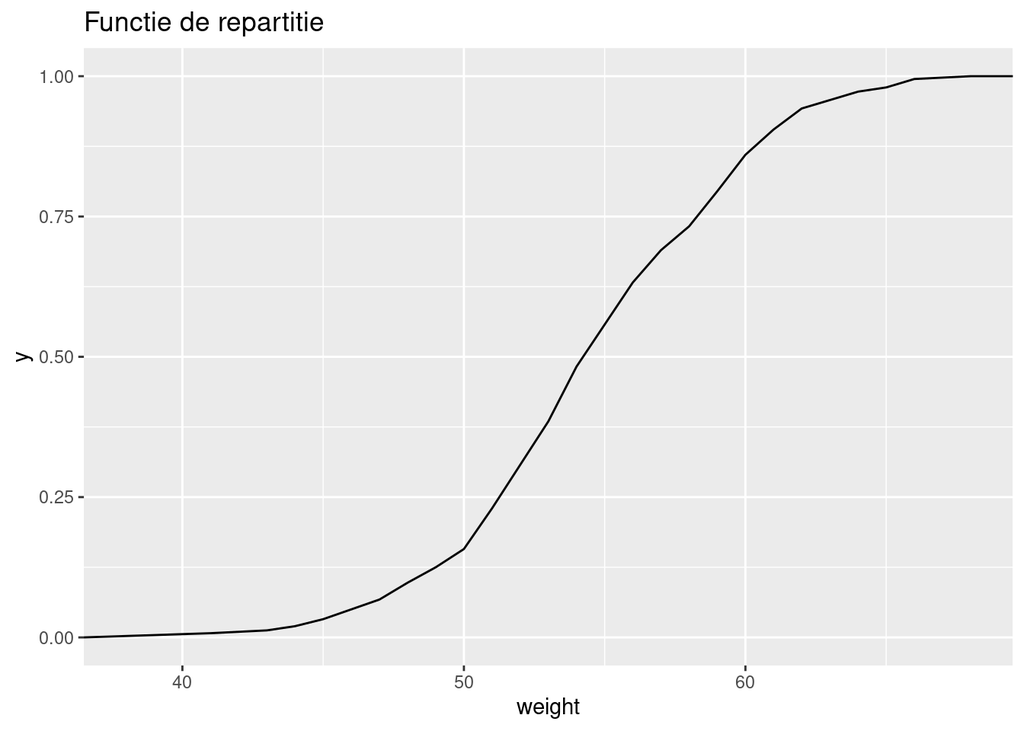

```r
                ggplot(df, aes(x=weight)) + stat_ecdf(geom = "line") + ggtitle("Functie de repartitie")
```

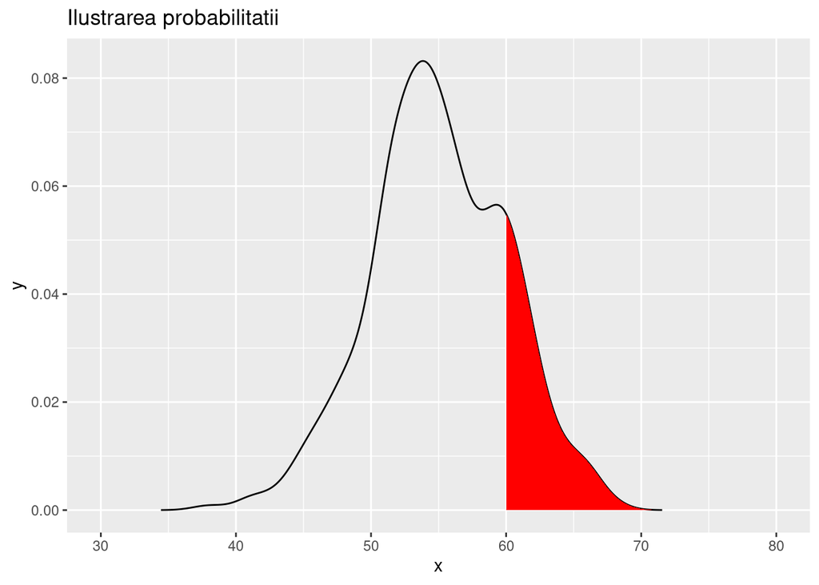

```r
                dat <- with(density(df$weight), data.frame(x, y))
                SelectProb = "P(x>=b)"
                if(SelectProb=="P(x<=a)"){
                    ggplot(data = dat, mapping = aes(x = x, y = y)) +
                        geom_line()+
                        geom_area(mapping = aes(x = ifelse(x<=a, x, 0)), fill = "red") +
                        xlim(30, 80) + ggtitle("Ilustrarea probabilitatii")
                }else if(SelectProb=="P(x>=b)"){
                    ggplot(data = dat, mapping = aes(x = x, y = y)) +
                        geom_line()+
                        geom_area(mapping = aes(x = ifelse(x>=b, x, 0)), fill = "red") +
                        xlim(30, 80) + ggtitle("Ilustrarea probabilitatii")
                }else{
                    ggplot(data = dat, mapping = aes(x = x, y = y)) +
                        geom_line()+
                        geom_area(mapping = aes(x = ifelse(x>=a & x<=b, x, 0)), fill = "red") +
                        xlim(30, 80) + ggtitle("Ilustrarea probabilitatii")
                }
```

```r
                if(SelectProb=="P(x<=a)"){
                        c("Probability: ", P11(a))

                }else if(SelectProb=="P(x>=b)"){
                        c("Probability: ", P11(b, param = 1))
                }else{
                        c("Probability: ", P11(a, b))
                }
```

```
## [1] "Probability: "     "0.158655253931457"
```

### Ex 12 (Repartitie uniforma pentru v.a. discreta)

Avem cu bile numerotate de la 1 la *interv*. Punem in urna bilele din [*aa,bb*] si ne interesam la probabilitatea de a le alege.

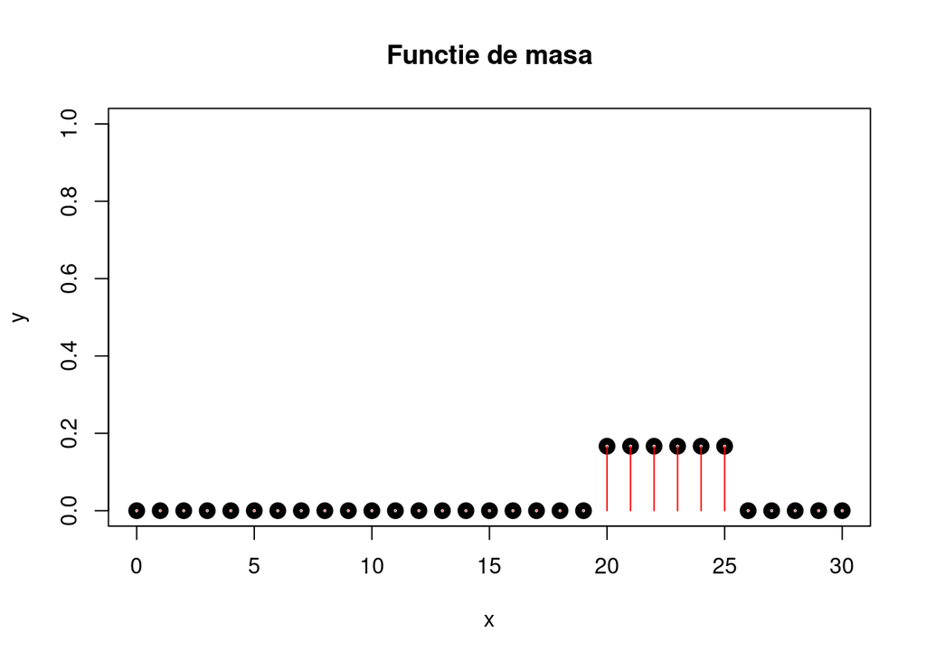

```r
            # 12 G~~~~~~~~~~~~~~~~~~~~~~~~~~~~~~~~~~~~~~~~~~~~~~~~~~~~~~~~~~~~~~~~~~~~~~~~~~~~~~~~~~~~~~~~~
            #
            aa = 20
            bb = 25
            a = 10
            b = 22
            interv = 30
            SelectProb="P(x>=b)"
            fm = function(x){
                if(x>=aa && x<=bb)
                    return(1/(bb-aa+1))
                else
                    return (0)
            }
            F = function(x){
                if(x>=aa && x<bb)
                    return((1-aa+floor(x))/(bb-aa+1))
                else if(x==bb)
                    return (1)
                else
                    return (0)
            }
            F = Vectorize(F, vectorize.args = "x")
            # fct masa
                x = seq(0, interv, by=1)
                y=fm(0)
                for(i in 1:interv){
                    y = c(y,fm(i))
                }
                plot(x, y, lwd=5, ylim = c(0,1), main="Functie de masa")
                segments(x, 0, x, y, col="red")
```

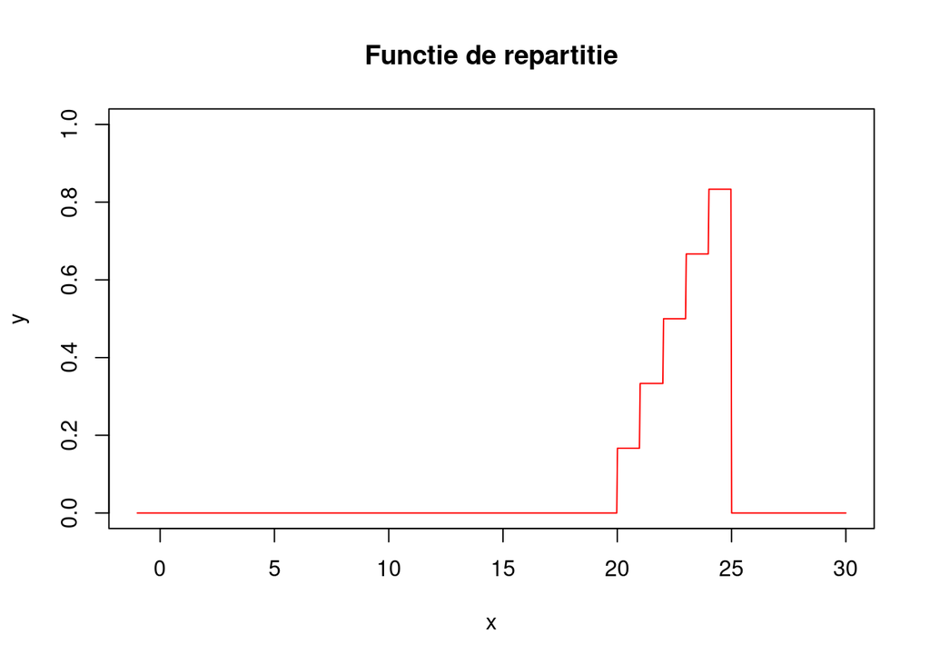

```r
            # fct rept
                x = seq(-1, interv, length.out = 1000)
                y = F(x)
                #y=F(0)
                #for(i in 1:50){
                #    y = c(y,F(i))
                #}
                #print(y)
                plot(x, y, type= "l", col="red", ylim = c(0,1), main="Functie de repartitie")
```

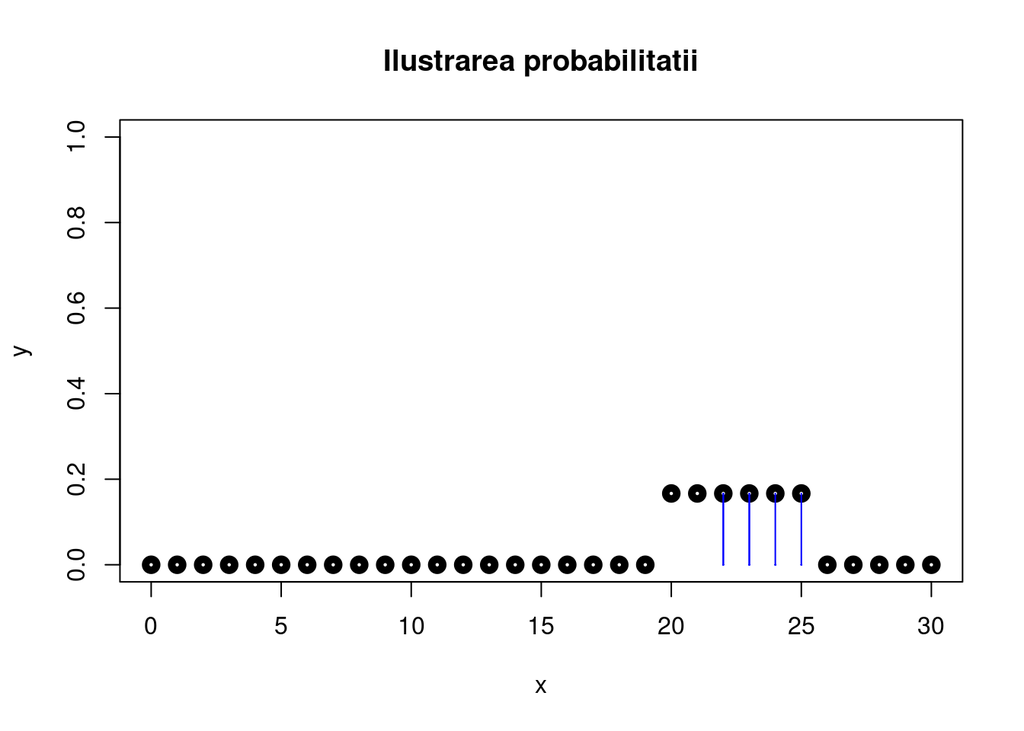

```r
                x = seq(0, interv, by=1)
                y=fm(0)
                for(i in 1:interv){
                    y = c(y,fm(i))
                }
                plot(x, y, lwd=5, ylim = c(0,1), main="Ilustrarea probabilitatii")
                #segments(x, 0, x, y, col="red")
                if(SelectProb=="P(x<=a)"){
                    x = seq(0, a, by=1)
                    y=fm(0)
                    for(i in 1:interv){
                        y = c(y,fm(i))
                    }
                    #plot(x, y, lwd=5, ylim = c(0,1))
                    x = seq(aa, a)
                    segments(x, 0, x, y, col="blue")
                }else if(SelectProb=="P(x>=b)"){
                    x = seq(b, interv, by=1)
                    y=fm(0)
                    for(i in 1:interv){
                        y = c(y,fm(i))
                    }
                    #plot(x, y, lwd=5, ylim = c(0,1))
                    x = seq(b, bb)
                    segments(x, 0, x, y, col="blue")
                }else{
                    x = seq(a, b, by=1)
                    y=fm(0)
                    for(i in 1:interv){
                        y = c(y,fm(i))
                    }
                    #plot(x, y, lwd=5, ylim = c(0,1))
                    x = seq(a, b)
                    segments(x, 0, x, y, col="blue")
                }
```

```r
            P = function(a, b=NULL, param=NULL)
            {
                if(is.null(b))
                {
                    if(is.null(param))
                    {
                        return(F(a))
                    }
                    else
                    {
                        return (1 - F(a))
                    }
                }
                else
                {
                    return (F(b) - F(a))
                }
            }
                if(SelectProb=="P(x<=a)"){
                        c("Probability: ", P(a))
                }else if(SelectProb=="P(x>=b)"){
                        c("Probability: ", P(b, param = 1)+fm(b))
                }else{
                        c("Probability: ", P(a, b)+fm(a))
                }
```

```
## [1] "Probability: "     "0.666666666666667"
```

### Ex13

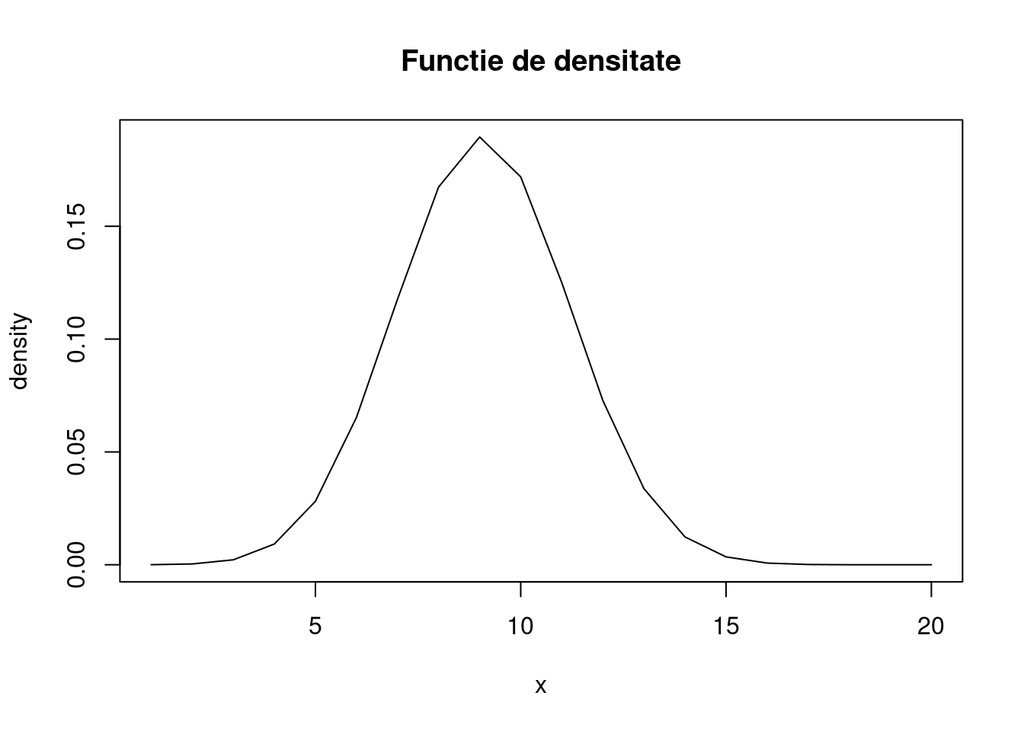

```r
            ex13_x = 14
            ex13_m = 70
            ex13_n = 84
            ex13_k = 20
            a = 9

            fd13 = function(x)
            {
                return(dhyper(x = x, m = ex13_m, n = ex13_n, k = ex13_k))
            }

            F13 = function(xx)
            {
                return (phyper(q = xx, m = ex13_m, n = ex13_n, k = ex13_k, lower.tail = TRUE))
            }

            fctMasa <- ({
                x = seq(1:ex13_k)
                density <- fd13(x)
                plot (x = x,y=density,type="l", main="Functie de densitate")
            })
```

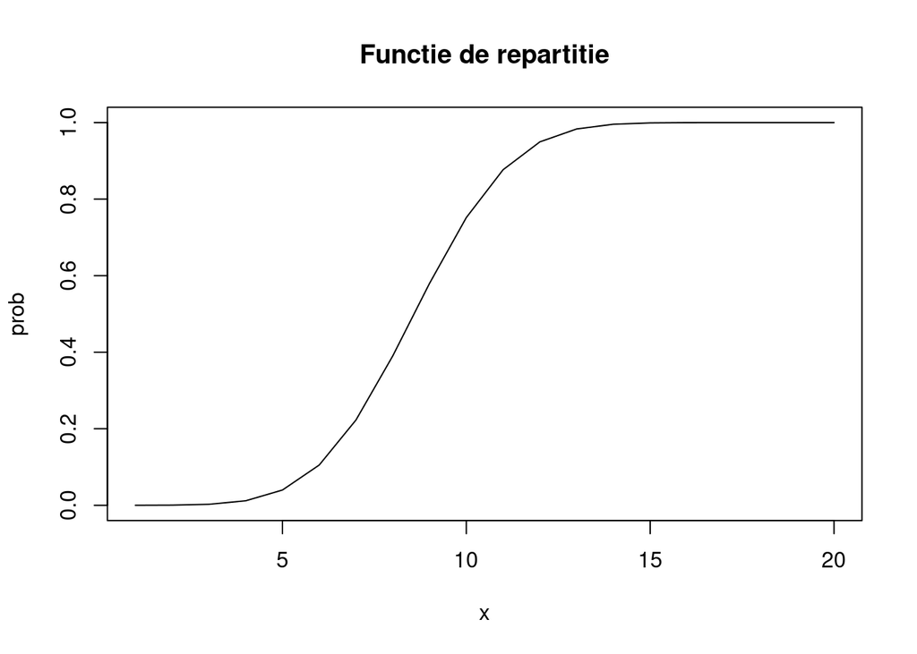

```r
            fctRep <- ({
                x = seq(1:ex13_k)
                prob <- F13(x)
                plot (x = x,y=prob,type="l", main="Functie de repartitie")
            })
```

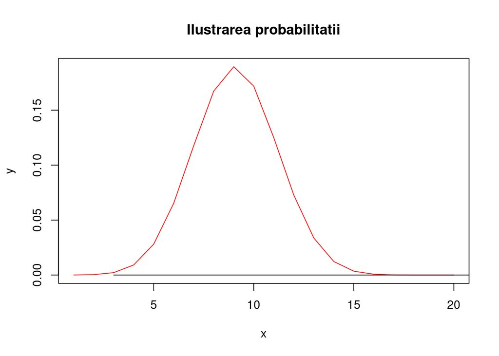

```r
            fctProb <-({
                x = seq(1:ex13_k)
                y = fd13(x)
                mini = min(y)
                plot(x, y, type= "l", col="red", main="Ilustrarea probabilitatii") # , ylim = c(0,1))
                if(SelectProb=="P(x<=a)"){
                    i <- x <= a
                    polygon(c(lim_inf,x[i],a), c(0,y[i],0), col="light blue")
                }else if(SelectProb=="P(x>=b)"){
                    i <- x >= b
                    polygon(c(b,x[i],lim_sup), c(0,y[i],0), col="light blue")
                }else{
                    x = seq(a , b)
                    y = fd13(x)
                    polygon(c(a,x,b), c(0,y,0), col="light blue")
                }
            })
```

```r
            P13 = function(a, b=NULL, param=NULL)
            {
                if(is.null(b))
                {
                    if(is.null(param))
                    {
                        return(F13(a))
                    }
                    else
                    {
                        return (1 - F13 (a))
                    }
                }
                else
                {
                    return (F13(b) - F13(a))
                }
            }

            SelectProb = "P(x<=a)"

            if(SelectProb=="P(x<=a)"){
                c("Probability: ", P13(a))
            }else if(SelectProb=="P(x>=b)"){
                c("Probability: ", P13(b, param = 1))
            }else{
                c("Probability: ", P13(a, b))
            }
```

```
## [1] "Probability: "    "0.57988772102763"
```

### Ex 14

Fiind dat pretul pe noapte al unor apartamente dintr-un oras, se calculeaza probabilitatea ca pretul unei camere sa fie intr-un anumit interval.

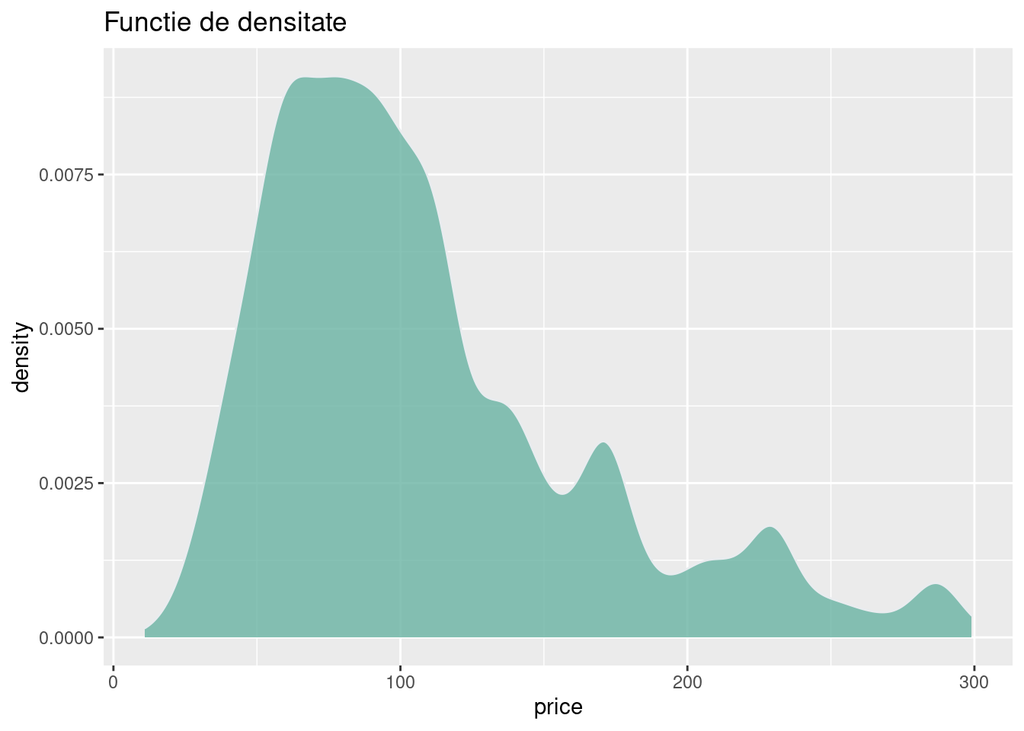

```r
            library(ggplot2)
            library(dplyr)
            b = 80
            data <- read.table("https://raw.githubusercontent.com/holtzy/data_to_viz/master/Example_dataset/1_OneNum.csv", header=TRUE)

            dat <- with(density(data$price), data.frame(x, y))

            f14 = function(datt){
                return(datt)
            }
                data %>%
                    filter( price<300) %>%
                    ggplot( aes(x=price)) +
                    geom_density(fill="#69b3a2", color="#e9ecef", alpha=0.8) + ggtitle("Functie de densitate")
```

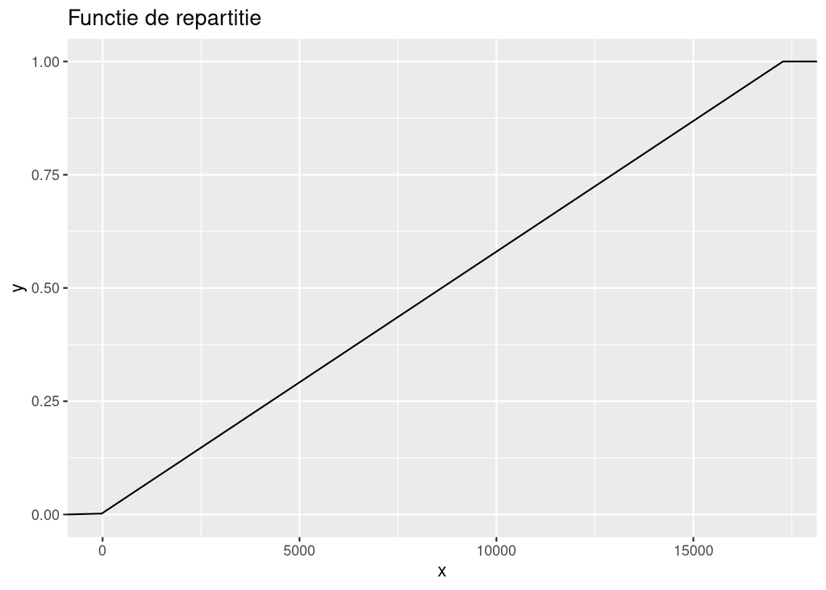

```r
                ggplot(dat, aes(x=x)) + stat_ecdf(geom = "line") + ggtitle("Functie de repartitie")
```

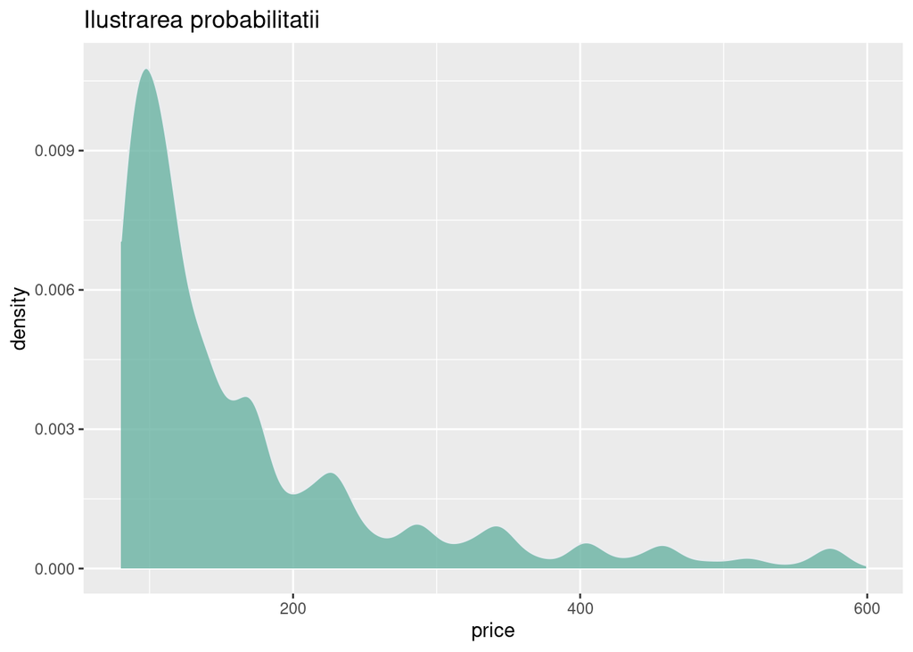

```r
                dat <- with(density(data$price), data.frame(x, y))
                SelectProb = "P(x>=b)"
                if(SelectProb=="P(x<=a)"){
                    data %>%
                        filter( price<=a) %>%
                        ggplot( aes(x=price)) +
                        geom_density(fill="#69b3a2", color="#e9ecef", alpha=0.8) + ggtitle("Ilustrarea probabilitatii")
                }else if(SelectProb=="P(x>=b)"){
                    data %>%
                        filter( price>=b & price < 600) %>%
                        ggplot( aes(x=price)) +
                        geom_density(fill="#69b3a2", color="#e9ecef", alpha=0.8) + ggtitle("Ilustrarea probabilitatii")
                }else{
                    data %>%
                        filter( price>=a & price <= b) %>%
                        ggplot( aes(x=price)) +
                        geom_density(fill="#69b3a2", color="#e9ecef", alpha=0.8) + ggtitle("Ilustrarea probabilitatii")
                }
```

```r
            F14 = function(xx){
                return(pnorm(q=xx, mean = 90, sd = 50))
            }
            P14 = function(a, b=NULL, param=NULL)
            {
                if(is.null(b))
                {
                    if(is.null(param))
                    {
                        return(F14(a))
                    }
                    else
                    {
                        return (1 - F14 (a))
                    }
                }
                else
                {
                    return (F14(b) - F14(a))
                }
            }
                if(SelectProb=="P(x<=a)"){
                        c("Probability: ", P14(a))
                }else if(SelectProb=="P(x>=b)"){
                        c("Probability: ", P14(b, param = 1))
                }else{
                        c("Probability: ", P14(a, b))
                }
```

```
## [1] "Probability: "     "0.579259709439103"
```

### Ex 15 (Repartitie geometrica pentru v.a. discreta)

Aruncam in mod repetat cu o moneda cu probabilitatea *pr* de a obtine cap. Fie *k* numarul de aruncari. Astfel, *X* va reprezenta numarul de aruncari pana obtinem primul succes

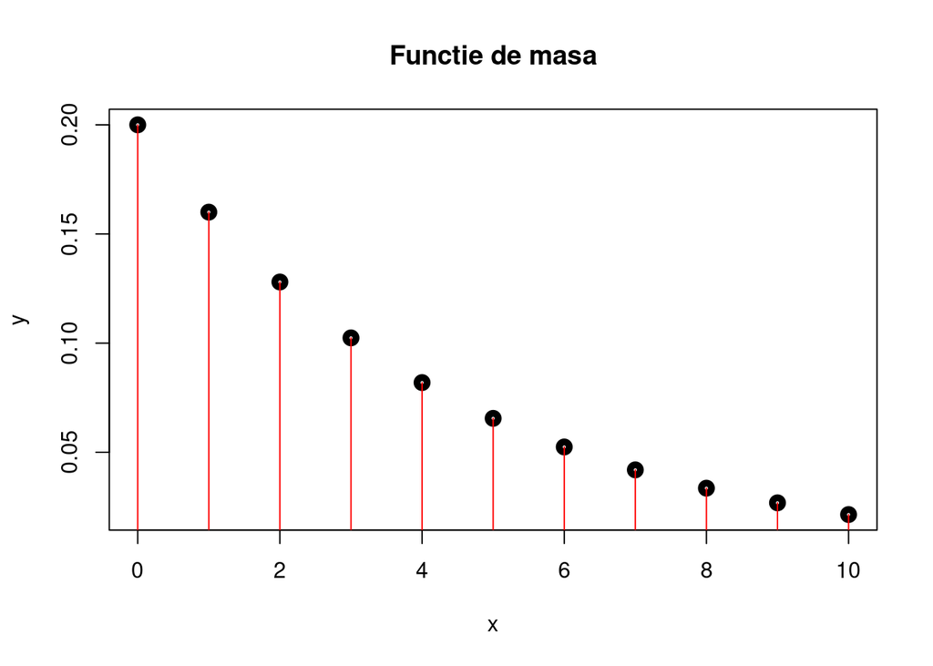

```r
            # 15 G~~~~~~~~~~~~~~~~~~~~~~~~~~~~~~~~~~~~~~~~~~~~~~~~~~~~~~~~~~~~~~~~~~~~~~~~~~~~~~~~~~~~~~~~~
            #
            a = 3
            b = 6
            pr = 0.2
            k = 10
            SelectProb="P(a<=x<=b)"
            fm = function(x){
                return(dgeom(x, prob = pr))
            }
            F = function(x){
                return(pgeom(x, prob = pr))
            }
            F = Vectorize(F, vectorize.args = "x")
            # fct masa
                x = seq(0, k, by=1)
                y=fm(0)
                for(i in 1:k){
                    y = c(y,fm(i))
                }
                plot(x, y, lwd=5, main="Functie de masa")
                segments(x, 0, x, y, col="red")
```

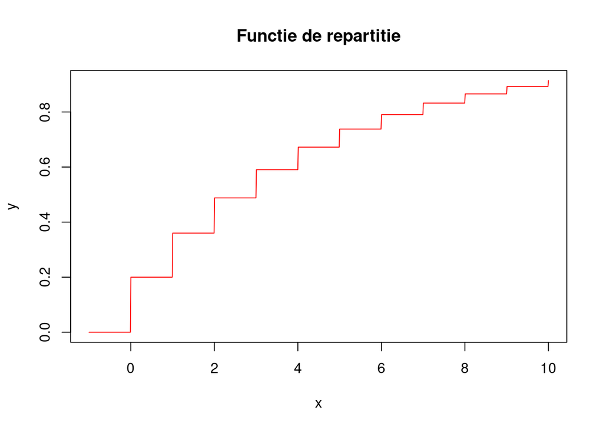

```r
            # fct rep
                x = seq(-1, k, length.out = 1000)
                y = F(x)
                plot(x, y, type= "l", col="red", main="Functie de repartitie")
```

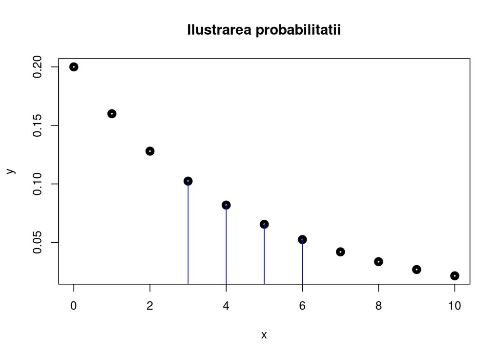

```r
                x = seq(0, k, by=1)
                y=fm(0)
                for(i in 1:k){
                    y = c(y,fm(i))
                }
                plot(x, y, lwd=5, main="Ilustrarea probabilitatii")
                #segments(x, 0, x, y, col="red")
                if(SelectProb=="P(x<=a)"){
                    x = seq(0, a, by=1)
                    y=fm(x)
                    #plot(x, y, lwd=5, ylim = c(0,1))
                    segments(x, 0, x, y, col="blue")
                }else if(SelectProb=="P(x>=b)"){
                    x = seq(b, k, by=1)
                    y=fm(x)
                    #plot(x, y, lwd=5, ylim = c(0,1))
                    segments(x, 0, x, y, col="blue")
                }else{
                    x = seq(a, b)
                    y=fm(x)
                    #plot(x, y, lwd=5, ylim = c(0,1))
                    segments(x, 0, x, y, col="blue")
                }
```

```r
            P = function(a, b=NULL, param=NULL)
            {
                if(is.null(b))
                {
                    if(is.null(param))
                    {
                        return(F(a))
                    }
                    else
                    {
                        return (1 - F(a))
                    }
                }
                else
                {
                    return (F(b) - F(a))
                }
            }
                if(SelectProb=="P(x<=a)"){
                        c("Probability: ", P(a))
                }else if(SelectProb=="P(x>=b)"){
                        c("Probability: ", P(b, param = 1)+fm(b))
                }else{
                        c("Probability: ", P(a, b)+fm(a))
                }
```

```
## [1] "Probability: " "0.3022848"
```

### Ex 16 (Repartitie poisson pentru v.a. discreta)

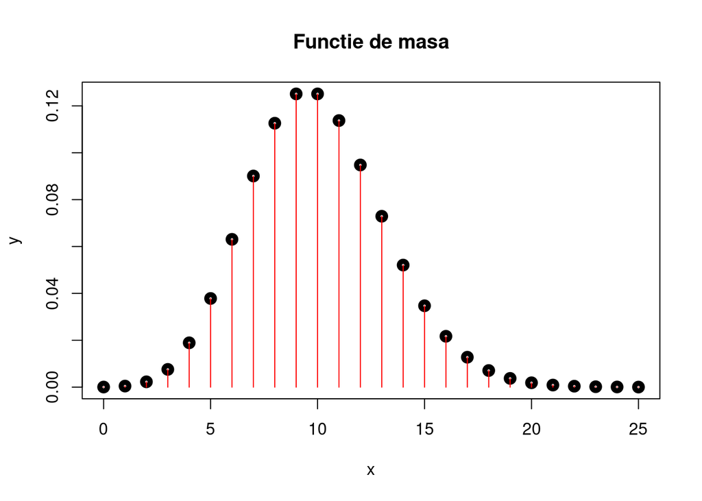

```r
            # 16 G~~~~~~~~~~~~~~~~~~~~~~~~~~~~~~~~~~~~~~~~~~~~~~~~~~~~~~~~~~~~~~~~~~~~~~~~~~~~~~~~~~~~~~~~~
            #
            a = 4
            b = 7
            lmb = 10
            k2 = 25

            SelectProb="P(x>=b)"
            fm = function(x){
                return(dpois(x, lambda = lmb))
            }
            F = function(x){
                return(ppois(x, lambda = lmb))
            }
            F = Vectorize(F, vectorize.args = "x")
            # fct masa
                x = seq(0, k2, by=1)
                y=fm(0)
                for(i in 1:k2){
                    y = c(y,fm(i))
                }
                plot(x, y, lwd=5, main="Functie de masa")
                segments(x, 0, x, y, col="red")
```

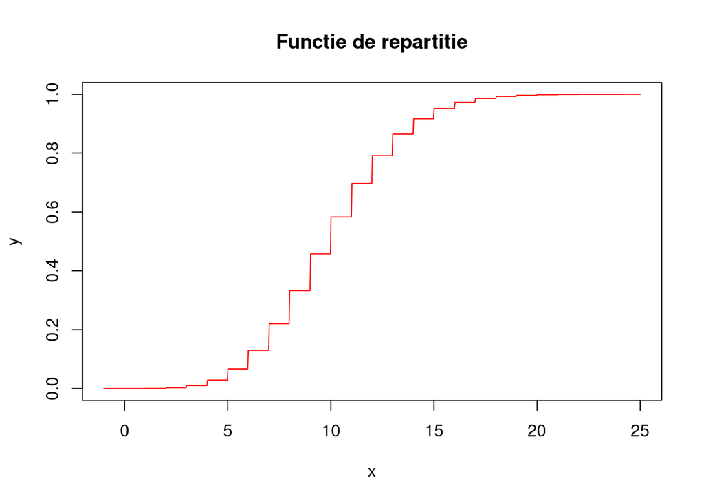

```r
            # fct rep
                x = seq(-1, k2, length.out = 1000)
                y = F(x)
                plot(x, y, type= "l", col="red", main="Functie de repartitie")
```

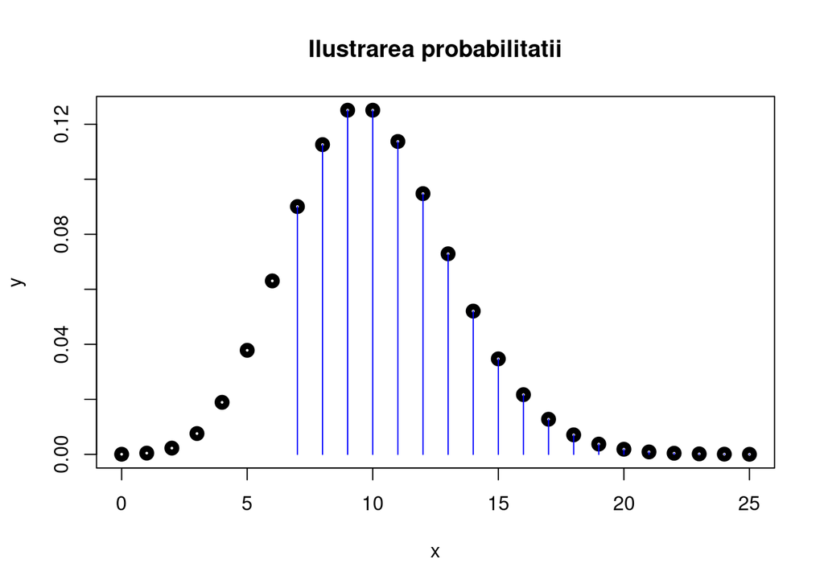

```r
                x = seq(0, k2, by=1)
                y=fm(0)
                for(i in 1:k2){
                    y = c(y,fm(i))
                }
                plot(x, y, lwd=5, main="Ilustrarea probabilitatii")
                #segments(x, 0, x, y, col="red")
                if(SelectProb=="P(x<=a)"){
                    x = seq(0, a, by=1)
                    y=fm(x)
                    #plot(x, y, lwd=5, ylim = c(0,1))
                    segments(x, 0, x, y, col="blue")
                }else if(SelectProb=="P(x>=b)"){
                    x = seq(b, k2, by=1)
                    y=fm(x)
                    #plot(x, y, lwd=5, ylim = c(0,1))
                    segments(x, 0, x, y, col="blue")
                }else{
                    x = seq(a, b)
                    y=fm(x)
                    #plot(x, y, lwd=5, ylim = c(0,1))
                    segments(x, 0, x, y, col="blue")
                }
```

```r
            P = function(a, b=NULL, param=NULL)
            {
                if(is.null(b))
                {
                    if(is.null(param))
                    {
                        return(F(a))
                    }
                    else
                    {
                        return (1 - F(a))
                    }
                }
                else
                {
                    return (F(b) - F(a))
                }
            }
                if(SelectProb=="P(x<=a)"){
                        c("Probability: ", P(a))
                }else if(SelectProb=="P(x>=b)"){
                        c("Probability: ", P(b, param = 1)+fm(b))
                }else{
                        c("Probability: ", P(a, b)+fm(a))
                }
```

```
## [1] "Probability: "     "0.869858579117517"
```

### Ex 17 (Repartitie negativ binomiala pentru v.a. discreta)

Modelam numarul de aruncari ale unei monede cu probabilitate *pr2* pana obtinem pentru prima oara *r* succese.

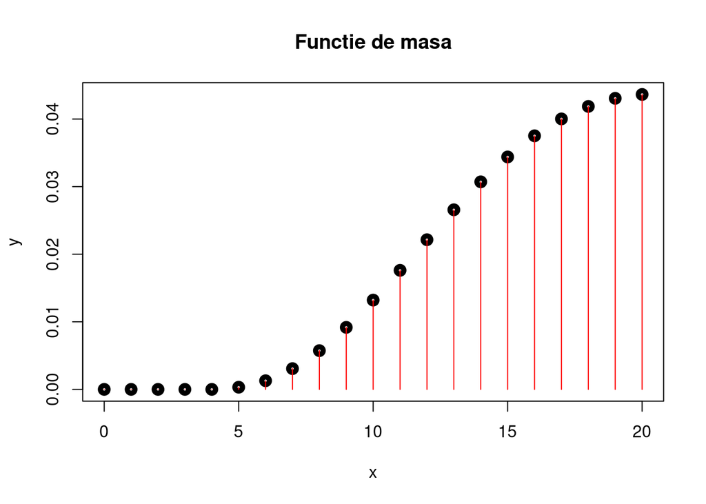

```r
            # 17 G~~~~~~~~~~~~~~~~~~~~~~~~~~~~~~~~~~~~~~~~~~~~~~~~~~~~~~~~~~~~~~~~~~~~~~~~~~~~~~~~~~~~~~~~~
            #
            a = 12
            b = 16
            pr2 = 0.2
            k3 = 20
            r = 5

            SelectProb="P(x<=a)"
            fm = function(x){
                if(x>=r)
                    return(factorial(x-1)/(factorial(r-1)*factorial(x-r))*(1-pr2)^(x-r)*pr2^r)
                else
                    return (0)
            }
            F = function(x){
                if(x>=r)
                    return (fm(x)+F(x-1))
                else return (0)
            }
            F = Vectorize(F, vectorize.args = "x")
            # fct masa
                x = seq(0, k3, by=1)
                y=fm(0)
                for(i in 1:k3){
                    y = c(y,fm(i))
                }
                plot(x, y, lwd=5, main="Functie de masa")
                segments(x, 0, x, y, col="red")
```

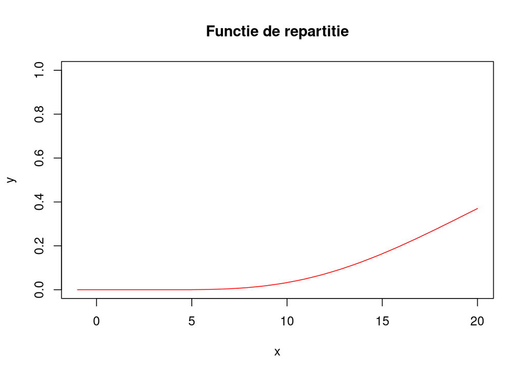

```r
            # fct rep
                x = seq(-1, k3, length.out = 1000)
                y = F(x)
                plot(x, y, type= "l", col="red", ylim = c(0,1), main="Functie de repartitie")
```

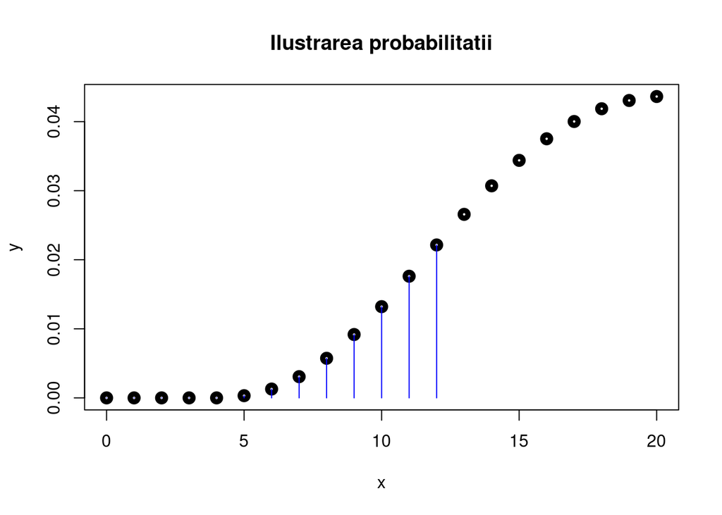

```r
                x = seq(0, k3, by=1)
                y=fm(0)
                for(i in 1:k3){
                    y = c(y,fm(i))
                }
                plot(x, y, lwd=5, main="Ilustrarea probabilitatii")
                #segments(x, 0, x, y, col="red")
                if(SelectProb=="P(x<=a)"){
                    x = seq(0, a, by=1)
                    y=fm(0)
                    for(i in 1:a){
                        y = c(y,fm(i))
                    }
                    #plot(x, y, lwd=5, ylim = c(0,1))
                    #x = seq(r, a)
                    segments(x, 0, x, y, col="blue")
                }else if(SelectProb=="P(x>=b)"){
                    x = seq(b, k3, by=1)
                    y=fm(b)
                    for(i in (b+1):k3){
                        y = c(y,fm(i))
                    }
                    #plot(x, y, lwd=5, ylim = c(0,1))
                    #x = seq(b, k3)
                    segments(x, 0, x, y, col="blue")
                }else{
                    x = seq(a, b, by=1)
                    y=fm(a)
                    for(i in (a+1):b){
                        y = c(y,fm(i))
                    }
                    #plot(x, y, lwd=5, ylim = c(0,1))
                    #x = seq(a, b)
                    segments(x, 0, x, y, col="blue")
                }
```

```r
            P = function(a, b=NULL, param=NULL)
            {
                if(is.null(b))
                {
                    if(is.null(param))
                    {
                        return(F(a))
                    }
                    else
                    {
                        return (1 - F(a))
                    }
                }
                else
                {
                    return (F(b) - F(a))
                }
            }
                if(SelectProb=="P(x<=a)"){
                        c("Probability: ", P(a))
                }else if(SelectProb=="P(x>=b)"){
                        c("Probability: ", P(b, param = 1)+fm(b))
                }else{
                        c("Probability: ", P(a, b)+fm(a))
                }
```

```
## [1] "Probability: " "0.07255549952"
```

### Ex 18

Aplicatie a repartitiei log-normale ce calculeaza probabilitatea in functie de medie si deviatia standard

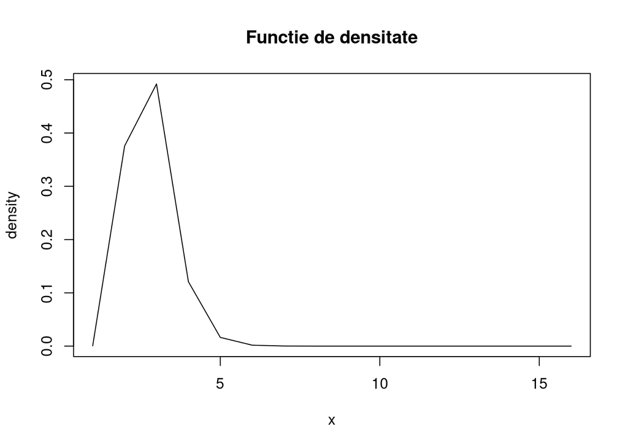

```r
            meanlog = 1
            sdlog = 0.25
            f18 = function(x){
                return(dlnorm(x=x, meanlog = meanlog, sdlog = sdlog, log = FALSE))
            }

            F18 = function(xx){
                return(plnorm(q=xx, meanlog = meanlog, sdlog = sdlog, log = FALSE))
            }

            x = seq(0:15)
            density <- f18(x)
            plot (x = x,y=density,type="l", main="Functie de densitate")
```

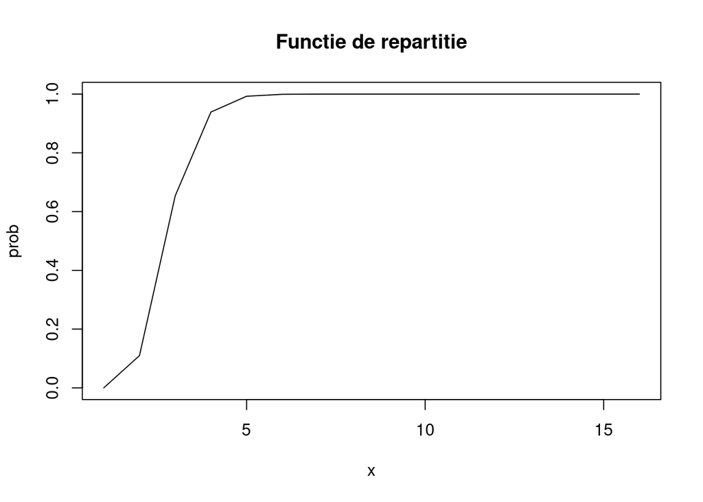

```r
            x = seq(0:15)
            prob <- F18(x)
            plot (x = x,y=prob,type="l", main="Functie de repartitie")
```

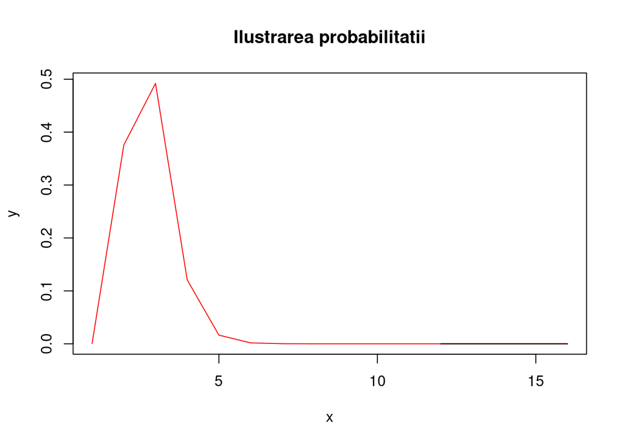

```r
            x = seq(0:15)
            y = f18(x)
            mini = min(y)
            plot(x, y, type= "l", col="red", main="Ilustrarea probabilitatii") # , ylim = c(0,1))
            SelectProb = "caz3"
            if(SelectProb=="P(x<=a)"){
                    i <- x <= a
                    polygon(c(lim_inf,x[i],a), c(0,y[i],0), col="light blue")
            }else if(SelectProb=="P(x>=b)"){
                    i <- x >= b
                    polygon(c(b,x[i],lim_sup), c(0,y[i],0), col="light blue")
            }else{
                    x = seq(a , b)
                    y = f18(x)
                    polygon(c(a,x,b), c(0,y,0), col="light blue")
                }
```

```r
            P18 = function(a, b=NULL, param=NULL)
            {
                if(is.null(b))
                {
                    if(is.null(param))
                    {
                        return(F18(a))
                    }
                    else
                    {
                        return (1 - F18 (a))
                    }
                }
                else
                {
                    return (F18(b) - F18(a))
                }
            }

                if(SelectProb=="P(x<=a)"){
                        c("Probability: ", P18(a))
                }else if(SelectProb=="P(x>=b)"){
                        c("Probability: ", P18(b, param = 1))
                }else{
                        c("Probability: ", P18(a, b))
                }
```

```
## [1] "Probability: "        "1.42769118749442e-09"
```

### Ex 19 (aproximarea binomiala prin Poisson)

Ilustram aproximarea binomiala prin Poisson data de numarul *n* si probabilitatea *p*

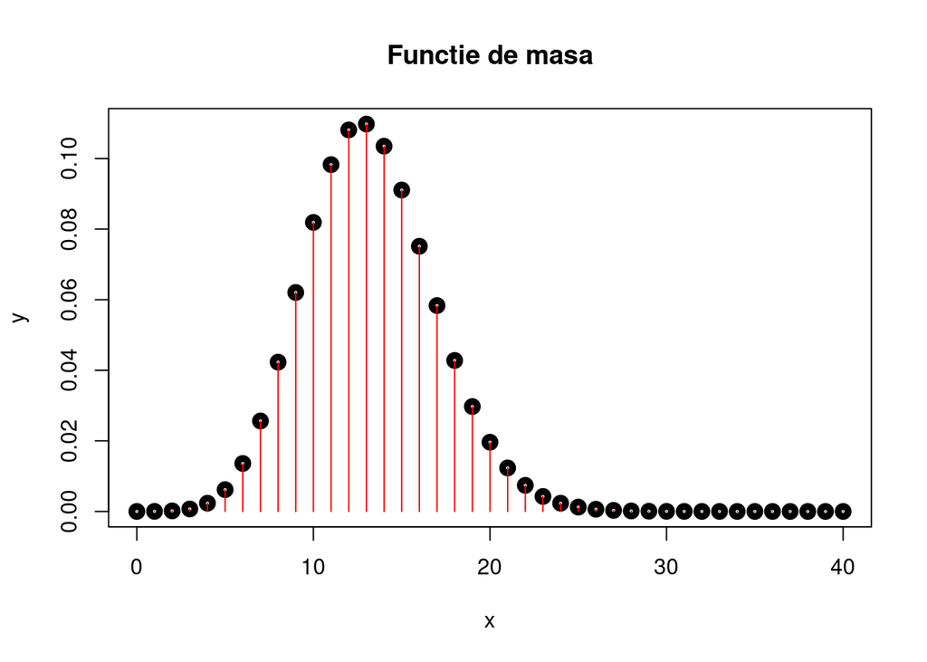

```r
            # 19 G~~~~~~~~~~~~~~~~~~~~~~~~~~~~~~~~~~~~~~~~~~~~~~~~~~~~~~~~~~~~~~~~~~~~~~~~~~~~~~~~~~~~~~~~~
            # Aproximarea binomiala prin Poisson
            a = 8
            b = 12
            n = 40
            pr3 = 0.33

            SelectProb="P(a<=x<=b)"
            fm = function(x){
                return(dpois(x, lambda = lmb))
            }
            lmbd = n*pr3
            fm = function(x){
                return(dpois(x, lambda = lmbd))
            }
            F = function(x){
                return(ppois(x, lambda = lmbd))
            }
            F = Vectorize(F, vectorize.args = "x")
            # fct masa
                x = seq(0, n, by=1)
                y=fm(0)
                for(i in 1:n){
                    y = c(y,fm(i))
                }
                plot(x, y, lwd=5, main="Functie de masa")
                segments(x, 0, x, y, col="red")
```

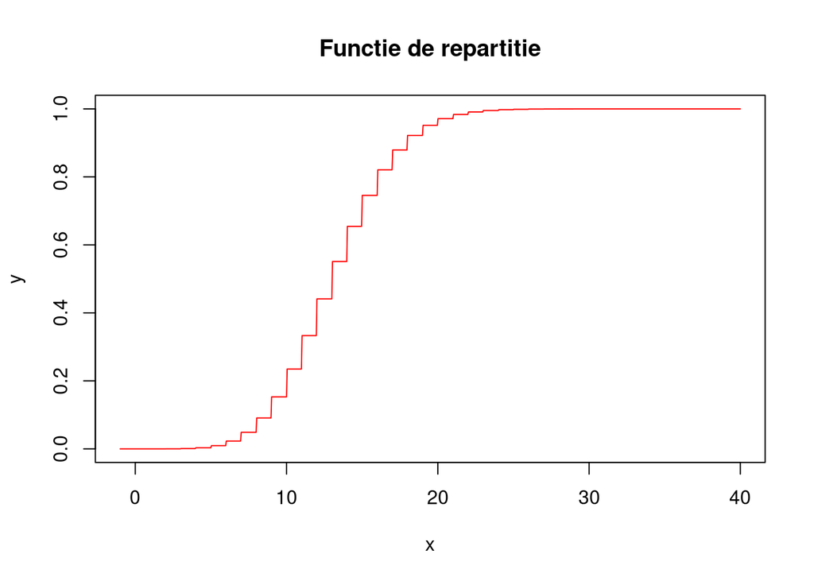

```r
            # fct rep
                x = seq(-1, n, length.out = 1000)
                y = F(x)
                #y=F(0)
                #for(i in 1:50){
                #    y = c(y,F(i))
                #}
                #print(y)
                plot(x, y, type= "l", col="red", main="Functie de repartitie")
```

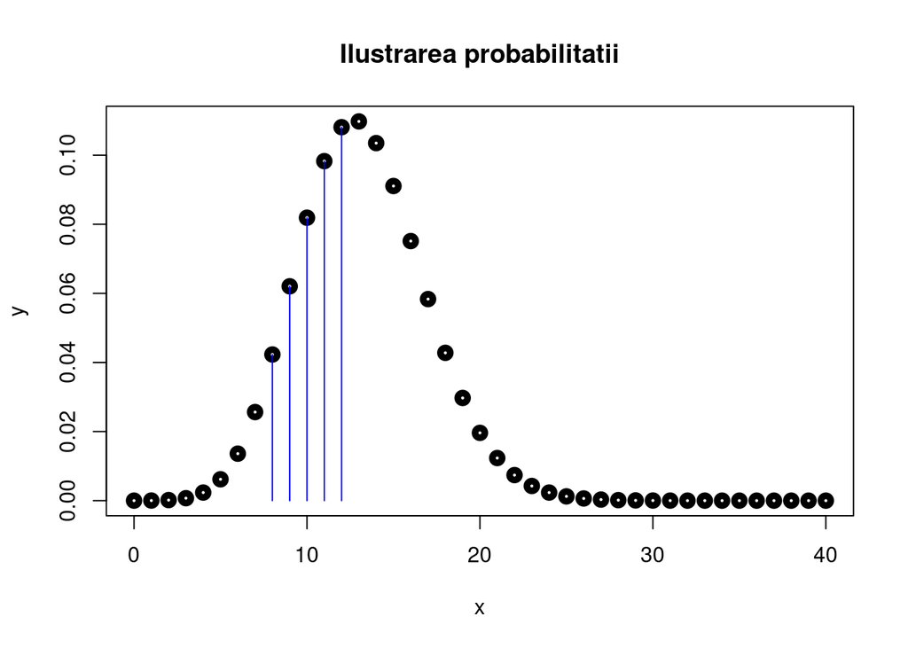

```r
                x = seq(0, n, by=1)
                y=fm(0)
                for(i in 1:n){
                    y = c(y,fm(i))
                }
                plot(x, y, lwd=5, main="Ilustrarea probabilitatii")
                #segments(x, 0, x, y, col="red")
                if(SelectProb=="P(x<=a)"){
                    x = seq(0, a, by=1)
                    y=fm(x)
                    #plot(x, y, lwd=5, ylim = c(0,1))
                    segments(x, 0, x, y, col="blue")
                }else if(SelectProb=="P(x>=b)"){
                    x = seq(b, n, by=1)
                    y=fm(x)
                    #plot(x, y, lwd=5, ylim = c(0,1))
                    segments(x, 0, x, y, col="blue")
                }else{
                    x = seq(a, b)
                    y=fm(x)
                    #plot(x, y, lwd=5, ylim = c(0,1))
                    segments(x, 0, x, y, col="blue")
                }
```

```r
            P = function(a, b=NULL, param=NULL)
            {
                if(is.null(b))
                {
                    if(is.null(param))
                    {
                        return(F(a))
                    }
                    else
                    {
                        return (1 - F(a))
                    }
                }
                else
                {
                    return (F(b) - F(a))
                }
            }
                if(SelectProb=="P(x<=a)"){
                        c("Probability: ", P(a))
                }else if(SelectProb=="P(x>=b)"){
                        c("Probability: ", P(b, param = 1)+fm(b))
                }else{
                        c("Probability: ", P(a, b)+fm(a))
                }
```

```
## [1] "Probability: "     "0.392641889535687"
```

### Ex 20

In medie, o persoana trimite un mandat postal o data la un numar theta de minute. Care este probabilitatea ca acea persoana sa trimita un numar alpha de mandate postale intr-o anumita perioada de timp?

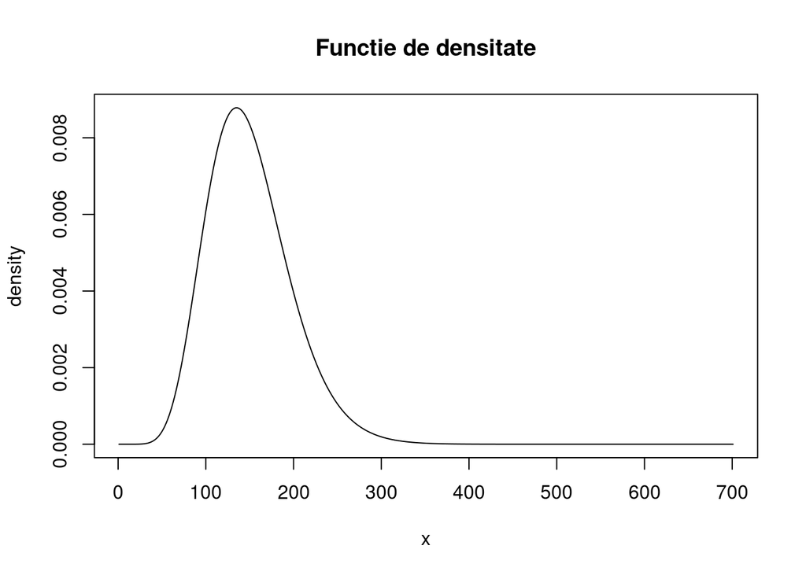

```r
      alpha = 10
      theta = 15

            f20 = function(x){
                return(dgamma(x = x, shape = alpha, scale = theta))
            }
            F20 = function(xx){
                return(pgamma(q = xx, shape = alpha, scale = theta))
            }

                x = seq(0:700)
                density <- f20(x)
                plot (x = x,y=density,type="l", main="Functie de densitate")
```

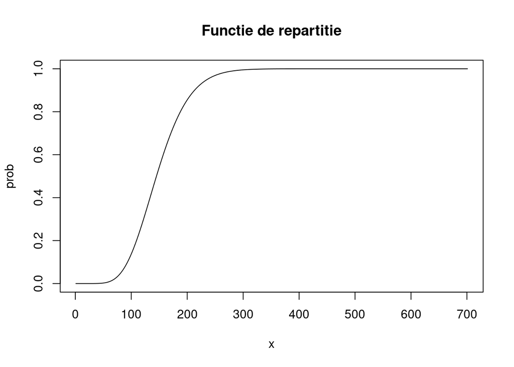

```r
                x = seq(0:700)
                prob <- F20(x)
                plot (x = x,y=prob,type="l", main="Functie de repartitie")
```

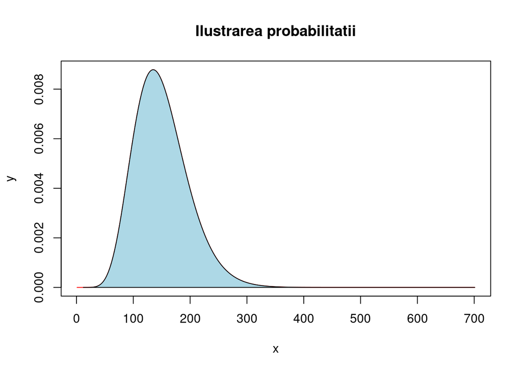

```r
                x = seq(0:700)
                y = f20(x)
                mini = min(y)
                plot(x, y, type= "l", col="red", main="Ilustrarea probabilitatii")
                SelectProb = "P(x>=b)"
                if(SelectProb=="P(x<=a)"){
                    i <- x <= a
                    polygon(c(0,x[i],a), c(0,y[i],0), col="light blue")
                }else if(SelectProb=="P(x>=b)"){
                    i <- x >= b
                    polygon(c(b,x[i],max(x)), c(0,y[i],0), col="light blue")
                }else{
                    x = seq(a , b)
                    y = f20(x)
                    polygon(c(a,x,b), c(0,y,0), col="light blue")
                }
```

```r
            P20 = function(a, b=NULL, param=NULL)
            {
                if(is.null(b))
                {
                    if(is.null(param))
                    {
                        return(F20(a))
                    }
                    else
                    {
                        return (1 - F20(a))
                    }
                }
                else
                {
                    return (F20(b) - F20(a))
                }
            }

                if(SelectProb=="P(x<=a)"){
                        c("Probability: ", P20(a))
                }else if(SelectProb=="P(x>=b)"){
                        c("Probability: ", P20(b, param = 1))
                }else{
                        c("Probability: ", P20(a, b))
                }
```

```
## [1] "Probability: "     "0.999999985668998"
```

### Ex 21

Consider an experiment with probability of success of p (ex21_p) and n (ex21_n) trials, i.e. X∼Bin(13,0.7).

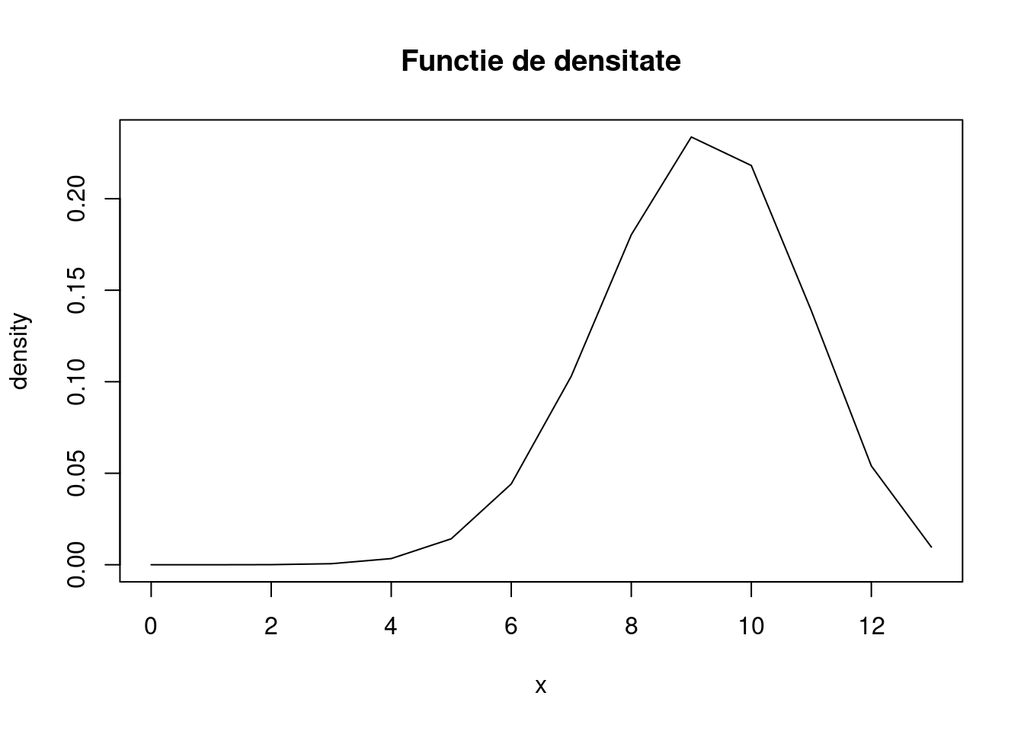

```r
            # 21
            ex21_n = 13
            ex21_p = 0.7
            a = 8
            b = 11

            f21 = function(x){
                return(dbinom(x, size = ex21_n, prob = ex21_p))
            }

            F21 = function(xx){
                return(pbinom(xx, size = ex21_n, prob = ex21_p))
            }

            fctMasa <- ({
                x = 0:ex21_n
                density <- f21(x)
                plot (x = x,y=density,type="l", main="Functie de densitate")
            })
```

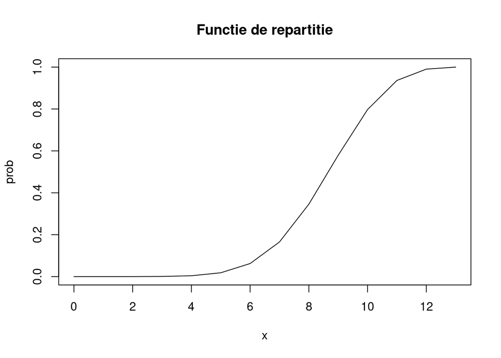

```r
            fctRep <- ({
                x = 0:ex21_n
                prob <- F21(x)
                plot (x = x,y=prob,type="l", main="Functie de repartitie")
            })
```

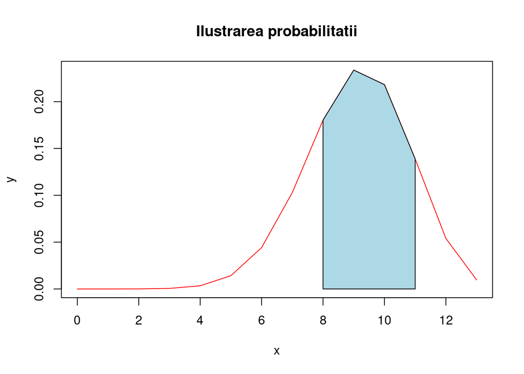

```r
            SelectProb = "P(a<=x<=b)"

            fctProb <-({
                x = 0:ex21_n
                y = f21(x)
                mini = min(y)
                plot(x, y, type= "l", col="red", main="Ilustrarea probabilitatii")

                if(SelectProb=="P(x<=a)"){
                    i <- x <= a
                    polygon(c(0,x[i],a), c(0,y[i],0), col="light blue")
                }else if(SelectProb=="P(x>=b)"){
                    i <- x >= b
                    polygon(c(b,x[i],max(x)), c(0,y[i],0), col="light blue")
                }else{
                    x = seq(a , b)
                    y = f21(x)
                    polygon(c(a,x,b), c(0,y,0), col="light blue")
                }

            })
```

```r
            P21 = function(a, b=NULL, param=NULL)
            {
                if(is.null(b))
                {
                    if(is.null(param))
                    {
                        return(F21(a))
                    }
                    else
                    {
                        return (1 - F21 (a))
                    }
                }
                else
                {
                    return (F21(b) - F21(a))
                }
            }



            if(SelectProb=="P(x<=a)"){
                  c("Probability: ", P21(a))
            }else if(SelectProb=="P(x>=b)"){
                  c("Probability: ", P21(b, param = 1))
            }else{
                  c("Probability: ", P21(a, b))
            }
```

```
## [1] "Probability: "   "0.5906436395769"
```